# How Can We Better Visualize Our Collective Progress Towards #SavingThePlanet?

### by: Ronak Patel

#### As we should all know (or not), Climate Change has been an accumulating issue ever since the Industrial Revolution with an even greater emphasis on it within the past few decades. While we make technological advancements by the day, many of them continue to harm the environment for the sake of "convenience" and monetary gain. In this tutorial, we will explore how means of transportation, regional industry, and other factors have come to impact air quality (as well as each other).

```python
import pandas as pd
import requests as req
import json
import matplotlib.pyplot as plt
from bs4 import BeautifulSoup
from urllib.parse import urlparse
import numpy as np
from datetime import datetime as dt
import folium
```

## Collecting & Parsing Data

#### The following is the process of collecting and parsing data into a format to be cleaned afterwards. Naming conventions are important here due to the fact that the data was collected from various sites (refer to 'Sources') and represent many different categories.

```python
# Annual Air Quality Index Data by County
aqi_2020 = pd.read_csv("Annual_AQI/annual_aqi_by_county_2020.csv")
aqi_2019 = pd.read_csv("Annual_AQI/annual_aqi_by_county_2019.csv")
aqi_2018 = pd.read_csv("Annual_AQI/annual_aqi_by_county_2018.csv")
aqi_2017 = pd.read_csv("Annual_AQI/annual_aqi_by_county_2017.csv")
aqi_2015 = pd.read_csv("Annual_AQI/annual_aqi_by_county_2015.csv")
aqi_2014 = pd.read_csv("Annual_AQI/annual_aqi_by_county_2014.csv")
aqi_2013 = pd.read_csv("Annual_AQI/annual_aqi_by_county_2013.csv")
aqi_2012 = pd.read_csv("Annual_AQI/annual_aqi_by_county_2012.csv")
aqi_2011 = pd.read_csv("Annual_AQI/annual_aqi_by_county_2011.csv")
aqi_2010 = pd.read_csv("Annual_AQI/annual_aqi_by_county_2010.csv")

aqis = [aqi_2020, aqi_2019, aqi_2018, aqi_2017, aqi_2015, aqi_2014, aqi_2013, aqi_2012, aqi_2011, aqi_2010]
annual_aqi = pd.concat(aqis)


# Daily Air Quality Index Data by County
aqi_2020 = pd.read_csv("Daily_AQI/daily_aqi_by_county_2020.csv")
aqi_2019 = pd.read_csv("Daily_AQI/daily_aqi_by_county_2019.csv")
aqi_2018 = pd.read_csv("Daily_AQI/daily_aqi_by_county_2018.csv")
aqi_2017 = pd.read_csv("Daily_AQI/daily_aqi_by_county_2017.csv")
aqi_2016 = pd.read_csv("Daily_AQI/daily_aqi_by_county_2016.csv")
aqi_2015 = pd.read_csv("Daily_AQI/daily_aqi_by_county_2015.csv")
aqi_2014 = pd.read_csv("Daily_AQI/daily_aqi_by_county_2014.csv")
aqi_2013 = pd.read_csv("Daily_AQI/daily_aqi_by_county_2013.csv")
aqi_2012 = pd.read_csv("Daily_AQI/daily_aqi_by_county_2012.csv")
aqi_2011 = pd.read_csv("Daily_AQI/daily_aqi_by_county_2011.csv")
aqi_2010 = pd.read_csv("Daily_AQI/daily_aqi_by_county_2010.csv")

aqis = [aqi_2020, aqi_2019, aqi_2018, aqi_2017, aqi_2016, aqi_2015, aqi_2014, aqi_2013, aqi_2012, aqi_2011, aqi_2010]
daily_aqi = pd.concat(aqis)
```

#### The categorizing of 'Good', 'Moderate', etc. days can be attributed to the following criteria: https://www.epa.gov/criteria-air-pollutants/naaqs-table & https://www.airnow.gov/aqi/aqi-basics/

```python
annual_aqi.head()
```

|  | State | County | Year | Days with AQI | Good Days | Moderate Days | Unhealthy for Sensitive Groups Days | Unhealthy Days | Very Unhealthy Days | Hazardous Days | Max AQI | 90th Percentile AQI | Median AQI | Days CO | Days NO2 | Days Ozone | Days SO2 | Days PM2.5 | Days PM10 |
| --- | --- | --- | --- | --- | --- | --- | --- | --- | --- | --- | --- | --- | --- | --- | --- | --- | --- | --- | --- |
| 0 | Alabama | Baldwin | 2020 | 168 | 159 | 9 | 0 | 0 | 0 | 0 | 74 | 48 | 37 | 0 | 0 | 130 | 0 | 38 | 0 |
| 1 | Alabama | Clay | 2020 | 58 | 54 | 4 | 0 | 0 | 0 | 0 | 86 | 49 | 24 | 0 | 0 | 0 | 0 | 58 | 0 |
| 2 | Alabama | DeKalb | 2020 | 242 | 234 | 8 | 0 | 0 | 0 | 0 | 90 | 46 | 37 | 0 | 0 | 230 | 0 | 12 | 0 |
| 3 | Alabama | Elmore | 2020 | 149 | 149 | 0 | 0 | 0 | 0 | 0 | 47 | 43 | 33 | 0 | 0 | 149 | 0 | 0 | 0 |
| 4 | Alabama | Etowah | 2020 | 169 | 161 | 8 | 0 | 0 | 0 | 0 | 92 | 46 | 35 | 0 | 0 | 137 | 0 | 32 | 0 |

```python
daily_aqi.head()
```

|  | State Name | county Name | State Code | County Code | Date | AQI | Category | Defining Parameter | Defining Site | Number of Sites Reporting |
| --- | --- | --- | --- | --- | --- | --- | --- | --- | --- | --- |
| 0 | Alabama | Baldwin | 1 | 3 | 2020-01-01 | 48 | Good | PM2.5 | 01-003-0010 | 1 |
| 1 | Alabama | Baldwin | 1 | 3 | 2020-01-04 | 13 | Good | PM2.5 | 01-003-0010 | 1 |
| 2 | Alabama | Baldwin | 1 | 3 | 2020-01-07 | 14 | Good | PM2.5 | 01-003-0010 | 1 |
| 3 | Alabama | Baldwin | 1 | 3 | 2020-01-10 | 39 | Good | PM2.5 | 01-003-0010 | 1 |
| 4 | Alabama | Baldwin | 1 | 3 | 2020-01-13 | 29 | Good | PM2.5 | 01-003-0010 | 1 |

```python
# GDP Data by County
gdp = pd.read_excel("GDP_data.xls")
gdp.drop(gdp.index[[9528,9529,9530,9531]], inplace=True)
```

```python
gdp.head()
```

|  | GeoFIPS | GeoName | Region | TableName | LineCode | IndustryClassification | Description | Unit | 2001 | 2002 | ... | 2010 | 2011 | 2012 | 2013 | 2014 | 2015 | 2016 | 2017 | 2018 | 2019 |
| --- | --- | --- | --- | --- | --- | --- | --- | --- | --- | --- | --- | --- | --- | --- | --- | --- | --- | --- | --- | --- | --- |
| 0 | "00000" | United States |  | CAGDP1 | 1.0 | ... | Real GDP (thousands of chained 2012 dollars) | Thousands of chained 2012 dollars | 13262079000 | 13493064000 | ... | 15598753000 | 15840664000 | 16197007000 | 16495369000 | 16912038000 | 17432170000 | 17730509000 | 18144105000 | 18687786000 | 19091662000 |
| 1 | "00000" | United States |  | CAGDP1 | 2.0 | ... | Chain-type quantity indexes for real GDP | Quantity index | 81.88 | 83.306 | ... | 96.306 | 97.8 | 100 | 101.842 | 104.415 | 107.626 | 109.468 | 112.021 | 115.378 | 117.872 |
| 2 | "00000" | United States |  | CAGDP1 | 3.0 | ... | Current-dollar GDP (thousands of current dollars) | Thousands of dollars | 10581822000 | 10936418000 | ... | 14992052000 | 15542582000 | 16197007000 | 16784851000 | 17527258000 | 18238301000 | 18745075000 | 19542980000 | 20611861000 | 21433226000 |
| 3 | "01000" | Alabama | 5 | CAGDP1 | 1.0 | ... | Real GDP (thousands of chained 2012 dollars) | Thousands of chained 2012 dollars | 157137932 | 161258050 | ... | 183014476 | 185666914 | 186553871 | 188814180 | 187568050 | 189428816 | 191523406 | 193692995 | 198053707 | 200829359 |
| 4 | "01000" | Alabama | 5 | CAGDP1 | 2.0 | ... | Chain-type quantity indexes for real GDP | Quantity index | 84.232 | 86.44 | ... | 98.103 | 99.525 | 100 | 101.212 | 100.544 | 101.541 | 102.664 | 103.827 | 106.164 | 107.652 |

5 rows × 27 columns

```python
# Annual State Emissions Data
state_em = pd.read_excel("State_Emissions.xlsx", skiprows=1)
#NOTE: emissions are in 1000/tons
state_em.head()
```

|  | State FIPS | State | Tier 1 Code | Tier 1 Description | Pollutant | emissions90 | emissions96 | emissions97 | emissions98 | emissions99 | ... | emissions11 | emissions12 | emissions13 | emissions14 | emissions15 | emissions16 | emissions17 | emissions18 | emissions19 | emissions20 |
| --- | --- | --- | --- | --- | --- | --- | --- | --- | --- | --- | --- | --- | --- | --- | --- | --- | --- | --- | --- | --- | --- |
| 0 | 1 | AL | 1 | FUEL COMB. ELEC. UTIL. | CO | 6.86859 | 8.06884 | 8.04705 | 8.12158 | 11.515260 | ... | 9.957645 | 9.642311 | 9.326977 | 9.011643 | 9.125182 | 9.238721 | 9.323161 | 9.323161 | 9.323161 | 9.323161 |
| 1 | 1 | AL | 1 | FUEL COMB. ELEC. UTIL. | NH3 | NaN | 0.01516 | 0.01605 | 0.01597 | 0.016510 | ... | 0.489319 | 0.488463 | 0.487606 | 0.486749 | 0.457457 | 0.428165 | 0.398873 | 0.398873 | 0.398873 | 0.398873 |
| 2 | 1 | AL | 1 | FUEL COMB. ELEC. UTIL. | NOX | 187.79386 | 219.00900 | 209.98918 | 198.66722 | 186.387100 | ... | 61.687148 | 57.768312 | 53.849475 | 49.930638 | 40.769235 | 31.607833 | 22.422130 | 24.087938 | 18.971049 | 13.752790 |
| 3 | 1 | AL | 1 | FUEL COMB. ELEC. UTIL. | PM10-PRI | 8.85994 | 9.28102 | 8.83472 | 8.37946 | 29.217020 | ... | 7.323322 | 6.469981 | 5.616641 | 4.763300 | 3.950869 | 3.138437 | 2.303326 | 2.303326 | 2.303326 | 2.303326 |
| 4 | 1 | AL | 1 | FUEL COMB. ELEC. UTIL. | PM25-PRI | 3.60246 | 4.36618 | 4.23529 | 4.00666 | 25.092193 | ... | 4.866091 | 4.407621 | 3.949151 | 3.490680 | 2.964636 | 2.438592 | 1.898368 | 1.898368 | 1.898368 | 1.898368 |

5 rows × 31 columns

```python
# Alternate Fuel Vehicle (AFV) Models Offered by Manufacturers
afv_models = pd.read_excel("AFV_Models.xlsx", skiprows=2)
afv_models.drop(afv_models.index[[58,59,60]], inplace=True)

# Sales of Various Types of Electric Vehicles
pev_sales = pd.read_excel("PEV_Sales.xlsx", skiprows=2)

# Alternate Fuel Stations, Open Date, & Locations
af_stations = pd.read_csv("AF_Stations.csv", dtype={'Street Address': "string"})
```

```python
afv_models.head()
```

|  | Unnamed: 0 | Manufacturer | 1991 | 1992 | 1993 | 1994 | 1995 | 1996 | 1997 | 1998 | ... | 2011 | 2012 | 2013 | 2014 | 2015 | 2016 | 2017 | 2018 | 2019 | Total |
| --- | --- | --- | --- | --- | --- | --- | --- | --- | --- | --- | --- | --- | --- | --- | --- | --- | --- | --- | --- | --- | --- |
| 0 | NaN | Acura | NaN | NaN | NaN | NaN | NaN | NaN | NaN | NaN | ... | NaN | NaN | 1.0 | 2.0 | NaN | 1 | 3.0 | 3.0 | 3.0 | 13.0 |
| 1 | NaN | Audi | NaN | NaN | NaN | NaN | NaN | NaN | NaN | NaN | ... | NaN | NaN | 6.0 | 6.0 | 7.0 | 7 | 4.0 | 1.0 | 7.0 | 38.0 |
| 2 | NaN | Bentley Motors | NaN | NaN | NaN | NaN | NaN | NaN | NaN | NaN | ... | 3.0 | 3.0 | 4.0 | 4.0 | 3.0 |  | NaN | NaN | NaN | 17.0 |
| 3 | NaN | BMW | NaN | NaN | NaN | NaN | NaN | NaN | NaN | NaN | ... | 3.0 | 1.0 | 3.0 | 6.0 | 6.0 | 5 | 7.0 | 9.0 | 9.0 | 50.0 |
| 4 | NaN | Buick | NaN | NaN | NaN | NaN | NaN | NaN | NaN | NaN | ... | 3.0 | 4.0 | 5.0 | 1.0 | 3.0 | 2 | NaN | 1.0 | 1.0 | 23.0 |

5 rows × 32 columns

```python
pev_sales.head()
```

|  | Unnamed: 0 | Vehicle | Type | 2011 | 2012 | 2013 | 2014 | 2015 | 2016 | 2017 | 2018 | 2019 | Total |
| --- | --- | --- | --- | --- | --- | --- | --- | --- | --- | --- | --- | --- | --- |
| 0 | NaN | Chevy Volt | PHEV | 7671.0 | 23461.0 | 23094.0 | 18805.0 | 15393.0 | 24739.0 | 20349.0 | 18306.0 | 4915.0 | 156733.0 |
| 1 | NaN | Nissan Leaf | EV | 9674.0 | 9819.0 | 22610.0 | 30200.0 | 17269.0 | 14006.0 | 11230.0 | 14715.0 | 12365.0 | 141888.0 |
| 2 | NaN | Smart ED | EV | 342.0 | 139.0 | 923.0 | 2594.0 | 1387.0 | 657.0 | 544.0 | 1219.0 | 680.0 | 8485.0 |
| 3 | NaN | Mitsubishi I EV | EV | 76.0 | 588.0 | 1029.0 | 196.0 | 115.0 | 94.0 | 6.0 | 0.0 | 0.0 | 2104.0 |
| 4 | NaN | BMW Active E | EV | 0.0 | 673.0 | 0.0 | 0.0 | 0.0 | 0.0 | 0.0 | 0.0 | 0.0 | 673.0 |

```python
af_stations.head()
```

|  | Fuel Type Code | Station Name | Street Address | Intersection Directions | City | State | ZIP | Plus4 | Station Phone | Status Code | ... | EV Pricing | EV Pricing (French) | LPG Nozzle Types | Hydrogen Pressures | Hydrogen Standards | CNG Fill Type Code | CNG PSI | CNG Vehicle Class | LNG Vehicle Class | EV On-Site Renewable Source |
| --- | --- | --- | --- | --- | --- | --- | --- | --- | --- | --- | --- | --- | --- | --- | --- | --- | --- | --- | --- | --- | --- |
| 0 | CNG | Alagasco - Montgomery Operations Center | 2951 Chestnut St | NaN | Montgomery | AL | 36107 | NaN | NaN | E | ... | NaN | NaN | NaN | NaN | NaN | B | 3600 | MD | NaN | NaN |
| 1 | CNG | PS Energy - Atlanta | 340 Whitehall St | From I-7585 N, exit 91 to Central Ave, left on... | Atlanta | GA | 30303 | NaN | 770-350-3000 | E | ... | NaN | NaN | NaN | NaN | NaN | Q | 3600 | MD | NaN | NaN |
| 2 | CNG | Metropolitan Atlanta Rapid Transit Authority | 2424 Piedmont Rd NE | NaN | Atlanta | GA | 30324 | NaN | NaN | E | ... | NaN | NaN | NaN | NaN | NaN | Q | 3000 | LD | NaN | NaN |
| 3 | CNG | United Parcel Service | 270 Marvin Miller Dr | NaN | Atlanta | GA | 30336 | NaN | NaN | E | ... | NaN | NaN | NaN | NaN | NaN | B | 3600 | HD | NaN | NaN |
| 4 | CNG | Clean Energy - Texas Department of Transportation | 7721A Washington St | I-10, Washington Ave exit, 1.5 blocks to the s... | Houston | TX | 77007 | NaN | 866-809-4869 | E | ... | NaN | NaN | NaN | NaN | NaN | Q | 3000 3600 | MD | NaN | NaN |

5 rows × 64 columns

## Cleaning Data

#### Now that the data has been collected and parsed, we must clean it for our purposes. That is, making the data more readable and efficient for running analysis over.

#### DF list for reference:

#### annual_aqi; AQI data summarized annually

#### daily_aqi; Daily AQI particulate data

#### state_em; Emissions by State

#### gdp; GDP data in USD & quantity index

#### afv_models; Alternate Fuel Vehicles by manufacturer

#### pev_sales; Electric vehicle sales by year (P=Plug-In)

#### af_stations; Alternate fuel stations, locations, and open dates

#### ANNUAL_AQI: for this dataset, we'll keep most of our attributes for further analysis. We can visualize this data on a state-by-state or year-over-year basis.

```python
annual_aqi.drop(['90th Percentile AQI'], axis=1, inplace=True)
annual_aqi.rename(columns={"Days with AQI":"Days Recorded"}, inplace=True)
annual_aqi.head()
```

|  | State | County | Year | Days Recorded | Good Days | Moderate Days | Unhealthy for Sensitive Groups Days | Unhealthy Days | Very Unhealthy Days | Hazardous Days | Max AQI | Median AQI | Days CO | Days NO2 | Days Ozone | Days SO2 | Days PM2.5 | Days PM10 |
| --- | --- | --- | --- | --- | --- | --- | --- | --- | --- | --- | --- | --- | --- | --- | --- | --- | --- | --- |
| 0 | Alabama | Baldwin | 2020 | 168 | 159 | 9 | 0 | 0 | 0 | 0 | 74 | 37 | 0 | 0 | 130 | 0 | 38 | 0 |
| 1 | Alabama | Clay | 2020 | 58 | 54 | 4 | 0 | 0 | 0 | 0 | 86 | 24 | 0 | 0 | 0 | 0 | 58 | 0 |
| 2 | Alabama | DeKalb | 2020 | 242 | 234 | 8 | 0 | 0 | 0 | 0 | 90 | 37 | 0 | 0 | 230 | 0 | 12 | 0 |
| 3 | Alabama | Elmore | 2020 | 149 | 149 | 0 | 0 | 0 | 0 | 0 | 47 | 33 | 0 | 0 | 149 | 0 | 0 | 0 |
| 4 | Alabama | Etowah | 2020 | 169 | 161 | 8 | 0 | 0 | 0 | 0 | 92 | 35 | 0 | 0 | 137 | 0 | 32 | 0 |

#### DAILY_AQI: for this dataset, we'll drop some site information. We will keep the State & County codes in the case that we choose to use them as identifiers.

```python
daily_aqi.drop(['Defining Parameter', 'Defining Site', 'Number of Sites Reporting'], axis=1, inplace=True)
daily_aqi.rename(columns={"State Name":"State","county Name":"County"}, inplace=True)
daily_aqi['Date'] = pd.to_datetime(daily_aqi['Date'], format='%Y-%m-%d')
daily_aqi.head()
```

|  | State | County | State Code | County Code | Date | AQI | Category |
| --- | --- | --- | --- | --- | --- | --- | --- |
| 0 | Alabama | Baldwin | 1 | 3 | 2020-01-01 | 48 | Good |
| 1 | Alabama | Baldwin | 1 | 3 | 2020-01-04 | 13 | Good |
| 2 | Alabama | Baldwin | 1 | 3 | 2020-01-07 | 14 | Good |
| 3 | Alabama | Baldwin | 1 | 3 | 2020-01-10 | 39 | Good |
| 4 | Alabama | Baldwin | 1 | 3 | 2020-01-13 | 29 | Good |

```python
state_em.drop(['State FIPS','Tier 1 Code','Tier 1 Description'], axis=1, inplace=True)
state_em['Emissions Unit'] = "1000/tons"
for title in list(state_em)[2:28]:
    if title[9] == '9':
        state_em.rename(columns={title:"19"+title[9:]}, inplace=True)
    else:
        state_em.rename(columns={title:"20"+title[9:]}, inplace=True)

state_em.replace(np.NaN, -0.1, inplace=True)

state_em.head()
```

|  | State | Pollutant | 1990 | 1996 | 1997 | 1998 | 1999 | 2000 | 2001 | 2002 | ... | 2012 | 2013 | 2014 | 2015 | 2016 | 2017 | 2018 | 2019 | 2020 | Emissions Unit |
| --- | --- | --- | --- | --- | --- | --- | --- | --- | --- | --- | --- | --- | --- | --- | --- | --- | --- | --- | --- | --- | --- |
| 0 | AL | CO | 6.86859 | 8.06884 | 8.04705 | 8.12158 | 11.515260 | 10.345005 | 9.807628 | 11.212116 | ... | 9.642311 | 9.326977 | 9.011643 | 9.125182 | 9.238721 | 9.323161 | 9.323161 | 9.323161 | 9.323161 | 1000/tons |
| 1 | AL | NH3 | -0.10000 | 0.01516 | 0.01605 | 0.01597 | 0.016510 | 0.016949 | 0.015926 | 0.648339 | ... | 0.488463 | 0.487606 | 0.486749 | 0.457457 | 0.428165 | 0.398873 | 0.398873 | 0.398873 | 0.398873 | 1000/tons |
| 2 | AL | NOX | 187.79386 | 219.00900 | 209.98918 | 198.66722 | 186.387100 | 182.334029 | 169.063668 | 162.457183 | ... | 57.768312 | 53.849475 | 49.930638 | 40.769235 | 31.607833 | 22.422130 | 24.087938 | 18.971049 | 13.752790 | 1000/tons |
| 3 | AL | PM10-PRI | 8.85994 | 9.28102 | 8.83472 | 8.37946 | 29.217020 | 28.920119 | 27.213014 | 26.039785 | ... | 6.469981 | 5.616641 | 4.763300 | 3.950869 | 3.138437 | 2.303326 | 2.303326 | 2.303326 | 2.303326 | 1000/tons |
| 4 | AL | PM25-PRI | 3.60246 | 4.36618 | 4.23529 | 4.00666 | 25.092193 | 24.408143 | 23.388713 | 22.522531 | ... | 4.407621 | 3.949151 | 3.490680 | 2.964636 | 2.438592 | 1.898368 | 1.898368 | 1.898368 | 1.898368 | 1000/tons |

5 rows × 29 columns

#### GDP: dropping arbitrary columns is all that is needed here

```python
gdp.drop(['GeoFIPS','Region','TableName','LineCode','IndustryClassification'], axis=1, inplace=True)
gdp.head()
```

|  | GeoName | Description | Unit | 2001 | 2002 | 2003 | 2004 | 2005 | 2006 | 2007 | ... | 2010 | 2011 | 2012 | 2013 | 2014 | 2015 | 2016 | 2017 | 2018 | 2019 |
| --- | --- | --- | --- | --- | --- | --- | --- | --- | --- | --- | --- | --- | --- | --- | --- | --- | --- | --- | --- | --- | --- |
| 0 | United States | Real GDP (thousands of chained 2012 dollars) | Thousands of chained 2012 dollars | 13262079000 | 13493064000 | 13879129000 | 14406382000 | 14912509000 | 15338257000 | 15626029000 | ... | 15598753000 | 15840664000 | 16197007000 | 16495369000 | 16912038000 | 17432170000 | 17730509000 | 18144105000 | 18687786000 | 19091662000 |
| 1 | United States | Chain-type quantity indexes for real GDP | Quantity index | 81.88 | 83.306 | 85.689 | 88.945 | 92.07 | 94.698 | 96.475 | ... | 96.306 | 97.8 | 100 | 101.842 | 104.415 | 107.626 | 109.468 | 112.021 | 115.378 | 117.872 |
| 2 | United States | Current-dollar GDP (thousands of current dollars) | Thousands of dollars | 10581822000 | 10936418000 | 11458246000 | 12213730000 | 13036637000 | 13814609000 | 14451860000 | ... | 14992052000 | 15542582000 | 16197007000 | 16784851000 | 17527258000 | 18238301000 | 18745075000 | 19542980000 | 20611861000 | 21433226000 |
| 3 | Alabama | Real GDP (thousands of chained 2012 dollars) | Thousands of chained 2012 dollars | 157137932 | 161258050 | 165250533 | 175916841 | 181871047 | 185337029 | 186499445 | ... | 183014476 | 185666914 | 186553871 | 188814180 | 187568050 | 189428816 | 191523406 | 193692995 | 198053707 | 200829359 |
| 4 | Alabama | Chain-type quantity indexes for real GDP | Quantity index | 84.232 | 86.44 | 88.581 | 94.298 | 97.49 | 99.348 | 99.971 | ... | 98.103 | 99.525 | 100 | 101.212 | 100.544 | 101.541 | 102.664 | 103.827 | 106.164 | 107.652 |

5 rows × 22 columns

#### AFV_MODELS: remove unnamed column and take care of NaN values

#### PEV_SALES: remove unnamed column and take care of NaN values

#### AF_STATIONS: remove all arbitrary columns and convert date to datetime

```python
afv_models.drop(['Unnamed: 0'], axis=1, inplace=True)
afv_models.replace(np.NaN, 0.0, inplace=True)
afv_models.replace('0', 0.0, inplace=True)
afv_models.replace('', 0.0, inplace=True)
afv_models.replace(' ', 0.0, inplace=True)
afv_models.head()
```

|  | Manufacturer | 1991 | 1992 | 1993 | 1994 | 1995 | 1996 | 1997 | 1998 | 1999 | ... | 2011 | 2012 | 2013 | 2014 | 2015 | 2016 | 2017 | 2018 | 2019 | Total |
| --- | --- | --- | --- | --- | --- | --- | --- | --- | --- | --- | --- | --- | --- | --- | --- | --- | --- | --- | --- | --- | --- |
| 0 | Acura | 0.0 | 0.0 | 0.0 | 0.0 | 0.0 | 0.0 | 0.0 | 0.0 | 0.0 | ... | 0.0 | 0.0 | 1.0 | 2.0 | 0.0 | 1.0 | 3.0 | 3.0 | 3.0 | 13.0 |
| 1 | Audi | 0.0 | 0.0 | 0.0 | 0.0 | 0.0 | 0.0 | 0.0 | 0.0 | 0.0 | ... | 0.0 | 0.0 | 6.0 | 6.0 | 7.0 | 7.0 | 4.0 | 1.0 | 7.0 | 38.0 |
| 2 | Bentley Motors | 0.0 | 0.0 | 0.0 | 0.0 | 0.0 | 0.0 | 0.0 | 0.0 | 0.0 | ... | 3.0 | 3.0 | 4.0 | 4.0 | 3.0 | 0.0 | 0.0 | 0.0 | 0.0 | 17.0 |
| 3 | BMW | 0.0 | 0.0 | 0.0 | 0.0 | 0.0 | 0.0 | 0.0 | 0.0 | 0.0 | ... | 3.0 | 1.0 | 3.0 | 6.0 | 6.0 | 5.0 | 7.0 | 9.0 | 9.0 | 50.0 |
| 4 | Buick | 0.0 | 0.0 | 0.0 | 0.0 | 0.0 | 0.0 | 0.0 | 0.0 | 0.0 | ... | 3.0 | 4.0 | 5.0 | 1.0 | 3.0 | 2.0 | 0.0 | 1.0 | 1.0 | 23.0 |

5 rows × 31 columns

```python
pev_sales.drop(['Unnamed: 0'], axis=1, inplace=True)
pev_sales.replace(np.NaN, 0, inplace=True)
pev_sales.head()
```

|  | Vehicle | Type | 2011 | 2012 | 2013 | 2014 | 2015 | 2016 | 2017 | 2018 | 2019 | Total |
| --- | --- | --- | --- | --- | --- | --- | --- | --- | --- | --- | --- | --- |
| 0 | Chevy Volt | PHEV | 7671.0 | 23461.0 | 23094.0 | 18805.0 | 15393.0 | 24739.0 | 20349.0 | 18306.0 | 4915.0 | 156733.0 |
| 1 | Nissan Leaf | EV | 9674.0 | 9819.0 | 22610.0 | 30200.0 | 17269.0 | 14006.0 | 11230.0 | 14715.0 | 12365.0 | 141888.0 |
| 2 | Smart ED | EV | 342.0 | 139.0 | 923.0 | 2594.0 | 1387.0 | 657.0 | 544.0 | 1219.0 | 680.0 | 8485.0 |
| 3 | Mitsubishi I EV | EV | 76.0 | 588.0 | 1029.0 | 196.0 | 115.0 | 94.0 | 6.0 | 0.0 | 0.0 | 2104.0 |
| 4 | BMW Active E | EV | 0.0 | 673.0 | 0.0 | 0.0 | 0.0 | 0.0 | 0.0 | 0.0 | 0.0 | 673.0 |

```python
cols = ['City','State','ZIP','Latitude','Longitude','Open Date']
af_stations = af_stations[cols]
af_stations['Open Date'] = pd.to_datetime(af_stations['Open Date'], format='%Y-%m-%d')
af_stations.head()
```

|  | City | State | ZIP | Latitude | Longitude | Open Date |
| --- | --- | --- | --- | --- | --- | --- |
| 0 | Montgomery | AL | 36107 | 32.367916 | -86.267021 | 2010-12-01 |
| 1 | Atlanta | GA | 30303 | 33.745843 | -84.398837 | 1994-07-15 |
| 2 | Atlanta | GA | 30324 | 33.821911 | -84.367461 | 1996-12-15 |
| 3 | Atlanta | GA | 30336 | 33.760256 | -84.543822 | 1997-01-01 |
| 4 | Houston | TX | 77007 | 29.779918 | -95.435385 | 1996-12-15 |

## Some Visualization...

#### Before we begin analysis, let's visualize some of our data to get a better understanding of what we're working with and possibly draw more ideas about what we can do with it.

#### ANNUAL_AQI: here is a summary of the types of days (as per AQI rating) that each year had on average. Note that there is no data for 2016 and that there is some factor influencing '2020' data.

#### UPDATE: instead of correcting a previous mistake, I thought it was interesting to note that the reason the bar graph did not look representative of anything was because I was assuming all number of days to be out of 365. This is not the case as 'Days Recorded' says otherwise and varies per row.

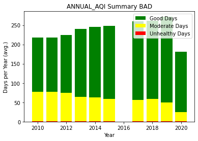

```python
# UPDATE: THIS IS THE BAD CODE
years = np.unique(annual_aqi['Year'])
gds=[]
mds=[]
uds=[]
for y in years:
    gds.append(annual_aqi[annual_aqi['Year']==y]['Good Days'].mean())
    mds.append(annual_aqi[annual_aqi['Year']==y]['Moderate Days'].mean())
    unh = (annual_aqi[annual_aqi['Year']==y]['Unhealthy Days'].mean() +
        annual_aqi[annual_aqi['Year']==y]['Very Unhealthy Days'].mean() +
        annual_aqi[annual_aqi['Year']==y]['Hazardous Days'].mean())
    uds.append(unh)


plt.bar(years, gds, color='green', label='Good Days')
plt.bar(years, mds, color='yellow', label='Moderate Days')
plt.bar(years, uds, color='red', label='Unhealthy Days')
plt.title('ANNUAL_AQI Summary BAD')
plt.xlabel('Year')
plt.ylabel('Days per Year (avg.)')
plt.legend()
plt.show()
```

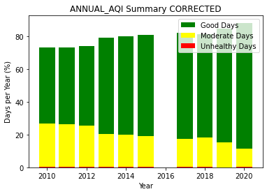

```python
# This is a corrected bar graph of the same information as above
annual_aqi['Good Days %'] = annual_aqi['Good Days']/annual_aqi['Days Recorded']*100
annual_aqi['Moderate Days %'] = (annual_aqi['Unhealthy for Sensitive Groups Days']+annual_aqi['Moderate Days'])/annual_aqi['Days Recorded']*100
annual_aqi['Unhealthy Days %'] = (annual_aqi['Hazardous Days']+annual_aqi['Very Unhealthy Days']+annual_aqi['Unhealthy Days'])/annual_aqi['Days Recorded']*100

years = np.unique(annual_aqi['Year'])
gds=[]
mds=[]
uds=[]
for y in years:
    gds.append(annual_aqi[annual_aqi['Year']==y]['Good Days %'].mean())
    mds.append(annual_aqi[annual_aqi['Year']==y]['Moderate Days %'].mean())
    uds.append(annual_aqi[annual_aqi['Year']==y]['Unhealthy Days %'].mean())

plt.bar(years, gds, color='green', label='Good Days')
plt.bar(years, mds, color='yellow', label='Moderate Days')
plt.bar(years, uds, color='red', label='Unhealthy Days')
plt.title('ANNUAL_AQI Summary CORRECTED')
plt.xlabel('Year')
plt.ylabel('Days per Year (%)')
plt.legend()
plt.show()
```

#### As observed, the bar graph looks much representative of what we should be expecting (no confirmation bias involved).

#### PEV_SALES: here is a year-to-year breakdown of EV and PEV vehicle sales. Maybe we will see some correlation with the AQI summary?

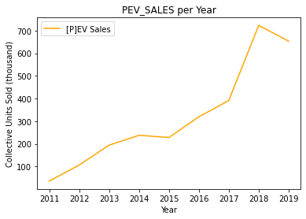

```python
years = list(pev_sales)[2:11]
sales = []
for y in years:
    sales.append(pev_sales[y].sum()/1000.0)

plt.plot(years, sales, color='orange', label='[P]EV Sales')
plt.title('PEV_SALES per Year')
plt.xlabel('Year')
plt.ylabel('Collective Units Sold (thousand)')
plt.legend()
plt.show()
```

#### AFV_MODELS: hmm... let's see if we can use unanalyzed data to try and find a relationship between sales and manufactures

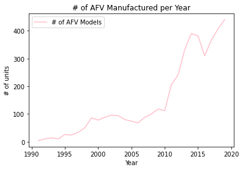

```python
years = list(afv_models)[1:30]
models = []
for y in years:
    afv_models = afv_models.astype({y: np.float})
    models.append(afv_models[y].sum())

plt.plot(years, models, color='pink', label='# of AFV Models')
plt.title('# of AFV Manufactured per Year')
plt.xlabel('Year')
plt.ylabel('# of units')
plt.legend()
plt.show()
```

## Exploring Data

```python
#t = {'State':[], 'Year':[], 'Emissions (1000/tons)':[]}
#for key,group in state_em.groupby(['State']):
#    t0 = []
#    for y in np.arange(1996,2021):
#        t['State'].append(key)
#        t['Year'].append(y)
#        t['Emissions (1000/tons)'].append(group[str(y)].sum())
#
#
#d = pd.DataFrame(data=t)
#
#plt.bar()
#plt.bar(years, d['Emissions (1000/tons)'], color='green', label='Good Days')
#plt.bar(years, d['Emissions (1000/tons)'], color='yellow', label='Moderate Days')
#plt.bar(years, d['Emissions (1000/tons)'], color='red', label='Unhealthy Days')
#plt.title('Emissions by State by Year')
#plt.xlabel('Year')
#plt.ylabel('Emissions (1000/ton)')
#plt.legend()

# Turn on the grid
#plt.minorticks_on()
#plt.grid(which='major', linestyle='-', linewidth='0.5', color='green')
#plt.grid(which='minor', linestyle=':', linewidth='0.5', color='black')

#plt.show()
```

```python
#station_map = folium.Map(location=[38, -96], zoom_start=3.7, legend=True)

#for i,row in af_stations.iterrows():
#    if row['Open Date'].year < 2000:
#        folium.CircleMarker(location=(row['Latitude'], row['Longitude']), radius=0.1, color='red', fill=False).add_to(station_map)
#    elif row['Open Date'].year < 2010:
#        folium.CircleMarker(location=(row['Latitude'], row['Longitude']), radius=0.1, color='orange', fill=False).add_to(station_map)
#    elif row['Open Date'].year < 2015:
#        folium.CircleMarker(location=(row['Latitude'], row['Longitude']), radius=0.1, color='green', fill=False).add_to(station_map)
#    else:
#        folium.CircleMarker(location=(row['Latitude'], row['Longitude']), radius=0.1, color='light blue', fill=False).add_to(station_map)

#station_map
```

```python
#pd.set_option('display.max_rows', None)
#pd.set_option('display.max_columns', None)
#pd.reset_option('display.max_rows')
#pd.reset_option('display.max_columns')
```

### Sources:

#### AQI Data - https://aqs.epa.gov/aqsweb/airdata/download_files.html

#### Alt. Fuels Data - https://afdc.energy.gov/data/

#### Transportation Census - https://data.census.gov/cedsci/table?q=Demographic%20by%20county&tid=ACSDT5Y2019.B08130&hidePreview=true

#### GDP Data - https://apps.bea.gov/regional/downloadzip.cfm